# Recoding addins

Julien Barnier

2020-11-30

The `questionr` packages provides addins for several recoding operations : recoding the levels of a factor or character variable, reordering the levels of a factor or character variable, dividing the range of a numeric variable into intervals.

The goal of these addins is to generate the recoding code with a small graphical interface. The code can then be inserted into a script and run (by design, nothing is executed by the addin in the global environment).

## Launching an addin

- by clicking on its name in the *Addins* menu
- by launching its function name in the Console
- by selecting a variable name in a script and then clicking on its name in the *Addins* menu
- by launching its function name in the Console with a variable as argument

In the first two cases, you will have to select the variable to be recoded manually, in the two last it will be done automatically for you.

Note that if your cursor is in a script when you launch an addin with the *Addins* menu, the generated code will be automatically inserted at you cursor position when clicking on *Done*.

## Levels recoding (`irec`)

The `irec` addin function can be launched with the *Levels recoding* entry of the *Addins* menu.

### Variable and settings

The first tab of the interface is called *Variable and setings*. Here you can select an object in you current environment, or a column in a data frame.

You can also select the name of the new object/data frame column, choose a recoding style, and the output object class.

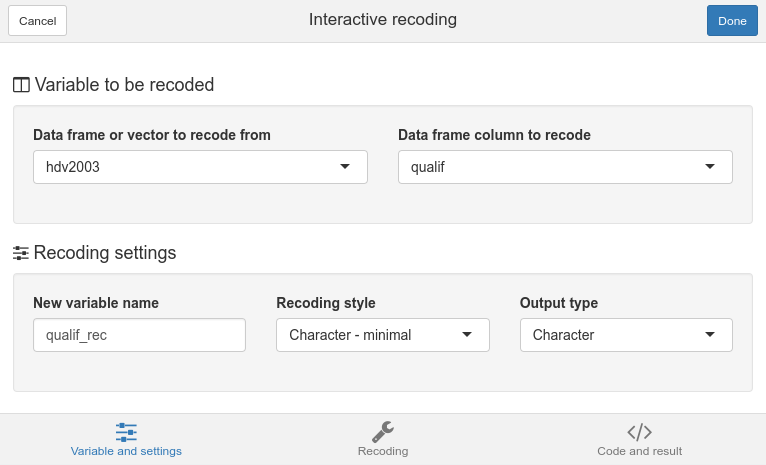

Variable and settings tab

### Recoding

The *Recoding* tab is where you can make the correspondance between old and new values. If you want to recode an existing level to `NA`, just type NA in the recoding field.

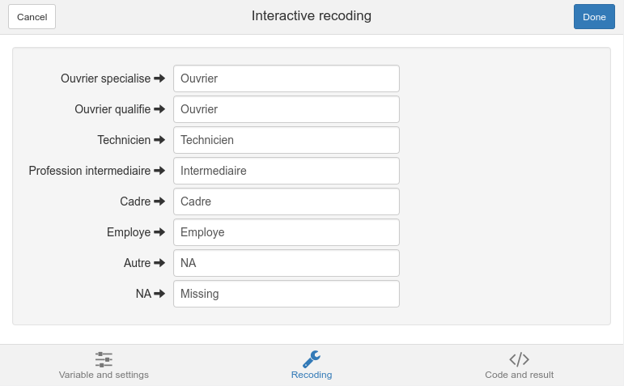

Recoding tab

### Code and result

Finally, the *Code and result* tab lets you see the generated code, and a cross tabulation between the original and recoded variables, to check if everything seems correct. When your recoding is good, you can click on the *Done* button : the generated code will then be inserted in your script (if the cursor was in the script window when launching the addin) and pasted into the Console window.

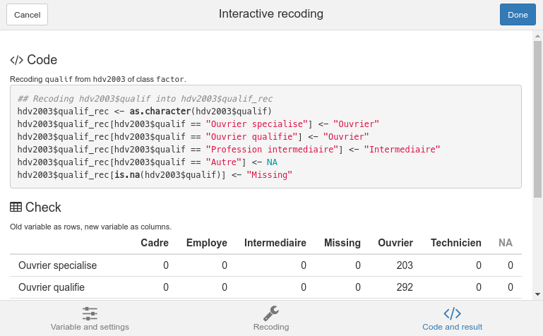

Code and result tab

## Levels ordering (`iorder`)

The `iorder` addin function can be launched with the *Levels ordering* entry of the *Addins* menu.

### Variable and settings

The first tab of the interface is called *Variable and setings*. Here you can select an object in you current environment, or a column in a data frame. You can also select the name of the new object/data frame column which will get the reordered variable (by default it will just replace the original object).

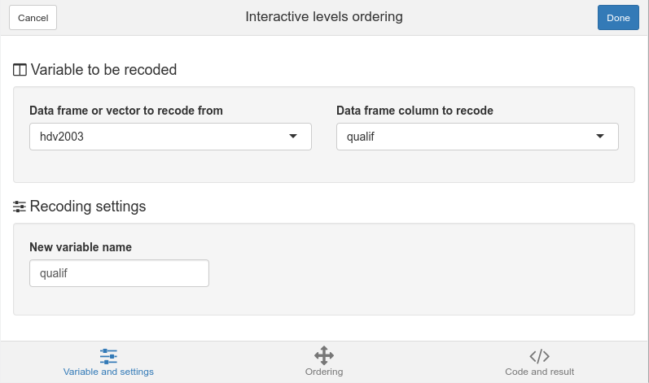

Variable and settings tab

### Ordering

The *Ordering* tab is where you can reorder your levels. Just drag and drop them with your mouse.

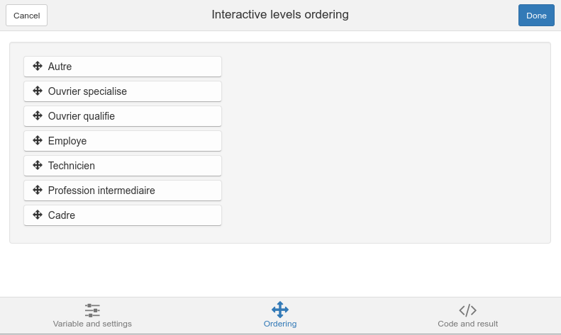

Ordering tab

### Code and result

Finally, the *Code and result* tab lets you see the generated code, and a contingency table of the resulting factor. When your result is good, you can click on the *Done* button : the generated code will then be inserted in your script (if the cursor was in the script window when launching the addin) and pasted into the Console window.

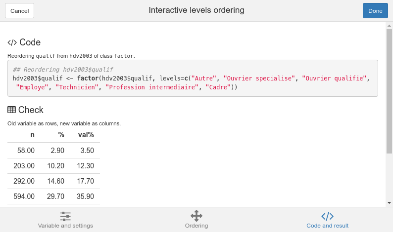

Code and result tab

## Numeric range dividing (`icut`)

### Variable and settings

The first tab of the interface is called *Variable and setings*. Here you can select an object in you current environment, or a column in a data frame. You can also select the name of the new object/data frame column which will get the new variable.

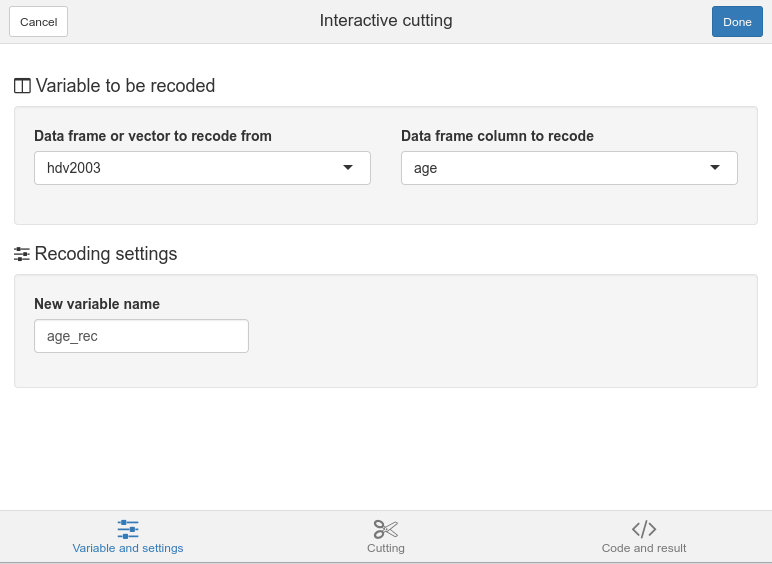

Variable and settings tab

### Cutting

The *Cutting* tab is where you will define the way to divide the variable range. First select a cutting method (the `Manual` method is the one used with the base `cut` function) and modify the options as you like. A dynamic histogram will show the class boundaries positions.

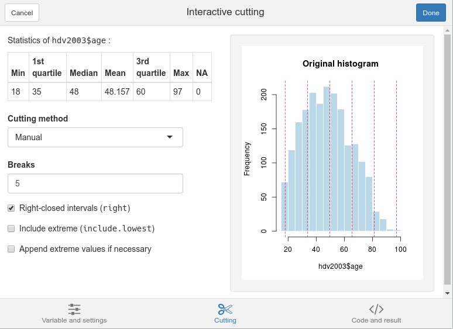

Cutting tab

### Code and result

Finally, the *Code and result* tab lets you see the generated code, and a contingency table and a barplot of the resulting factor. When your result is good, you can click on the *Done* button : the generated code will then be inserted in your script (if the cursor was in the script window when launching the addin) and pasted into the Console window.

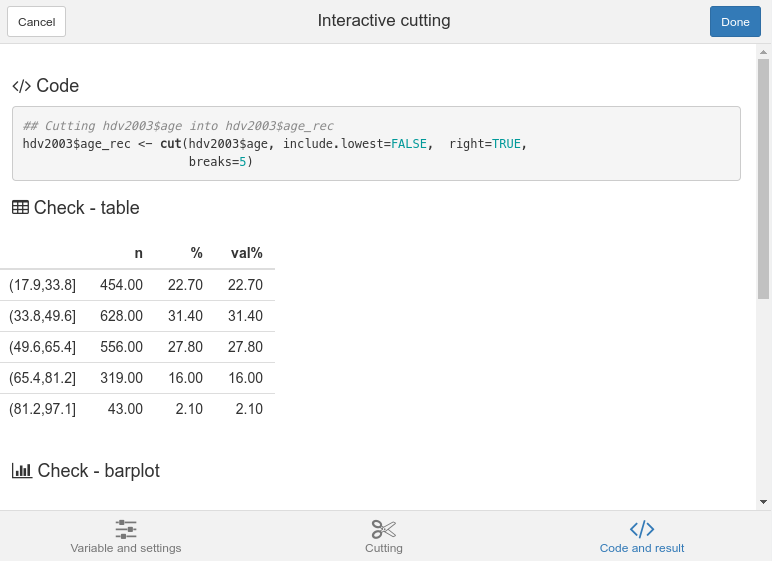

Code and result tab